# TP - Aeropuertos

Laboratorio de Datos

Grupo 8: Cosarinsky Matias, Remus Ezequiel, Reyes Andres

# Viajes más Frecuentes

En esta parte, utilizaremos los datos de `Origen` y `Destino` y la frecuencia de de viaje de un lugar a otro, es decir la cantidad de veces que un `Origen` esta relacionado con un `Destino`.

Para esto, vamos a utilizar grafos, y los visualizaremos tanto con grafos dirigidos como grafos no dirigidos. Estos se ara con las librerias del paquete `ggraph`.

```r
# Corro las librerias necesarias
library(ggraph)
library(ggplot2)
# library(ggthemes)
library(dplyr)
library(igraph)

# Leo el csv con los datos
df.vuelos <- read.csv("vuelos_2021.csv")

df.vuelos
```

| Origen | Destino | Aeronave | Horario.x | Tipo.de.Movimiento.x | Pasajeros.x | distancia.km.x | lat.origen | long.origen | Horario.y | Tipo.de.Movimiento.y | Pasajeros.y | distancia.km.y | lat.destino | long.destino | tiempo.vuelo | Velocidad.kmhs |
| --- | --- | --- | --- | --- | --- | --- | --- | --- | --- | --- | --- | --- | --- | --- | --- | --- |
| AER | BAR | AIB-A320-232 | 2021-07-11 16:06:00 | Despegue | 80 | 1450.8179 | -34.56055 | -58.41343 | 2021-07-11 18:21:00 | Aterrizaje | 80 | 1450.8179 | -41.15032 | -71.15931 | 2.25000000 | 644.8080 |
| AER | BAR | AIB-A320-232 | 2021-05-15 15:16:00 | Despegue | 69 | 1450.8179 | -34.56055 | -58.41343 | 2021-05-15 17:21:00 | Aterrizaje | 61 | 1450.8179 | -41.15032 | -71.15931 | 2.08333333 | 696.3926 |
| AER | BAR | AIB-A320-232 | 2021-07-26 14:38:00 | Despegue | 83 | 1450.8179 | -34.56055 | -58.41343 | 2021-07-26 16:41:00 | Aterrizaje | 83 | 1450.8179 | -41.15032 | -71.15931 | 2.05000000 | 707.7161 |
| AER | BAR | AIB-A320-232 | 2021-03-31 15:27:00 | Despegue | 79 | 1450.8179 | -34.56055 | -58.41343 | 2021-03-31 17:22:00 | Aterrizaje | 79 | 1450.8179 | -41.15032 | -71.15931 | 1.91666667 | 756.9485 |
| AER | BAR | AIB-A320-232 | 2021-07-31 17:16:00 | Despegue | 68 | 1450.8179 | -34.56055 | -58.41343 | 2021-07-31 17:40:00 | Aterrizaje | 60 | 1450.8179 | -41.15032 | -71.15931 | 0.40000000 | 3627.0448 |
| AER | BAR | AIB-A320-232 | 2021-07-31 17:16:00 | Despegue | 68 | 1450.8179 | -34.56055 | -58.41343 | 2021-07-31 19:16:00 | Aterrizaje | 68 | 1450.8179 | -41.15032 | -71.15931 | 2.00000000 | 725.4090 |
| AER | BAR | AIB-A320-232 | 2021-04-21 16:27:00 | Despegue | 54 | 1450.8179 | -34.56055 | -58.41343 | 2021-04-21 18:24:00 | Aterrizaje | 54 | 1450.8179 | -41.15032 | -71.15931 | 1.95000000 | 744.0092 |
| AER | BAR | AIB-A320-232 | 2021-07-31 15:40:00 | Despegue | 60 | 1450.8179 | -34.56055 | -58.41343 | 2021-07-31 17:40:00 | Aterrizaje | 60 | 1450.8179 | -41.15032 | -71.15931 | 2.00000000 | 725.4090 |
| AER | BAR | AIB-A320-232 | 2021-07-31 15:40:00 | Despegue | 60 | 1450.8179 | -34.56055 | -58.41343 | 2021-07-31 19:16:00 | Aterrizaje | 68 | 1450.8179 | -41.15032 | -71.15931 | 3.60000000 | 403.0050 |
| AER | BAR | AIB-A320-232 | 2021-04-26 14:05:00 | Despegue | 53 | 1450.8179 | -34.56055 | -58.41343 | 2021-04-26 16:02:00 | Aterrizaje | 53 | 1450.8179 | -41.15032 | -71.15931 | 1.95000000 | 744.0092 |

[output cut: 990 more lines]

El `dataset` ya esta ordenado por *Origen* y *Destino*.

Ahora, añadimos una columna contando la frecuencias de estos viajes.

```r
frec.viajes <- df.vuelos %>% select(Origen, Destino) %>% group_by(Origen,Destino) %>% summarise(n=n())
frec.viajes
```

| Origen | Destino | n |
| --- | --- | --- |
| AER | BAR | 748 |
| AER | BCA | 76 |
| AER | CAT | 26 |
| AER | CBA | 766 |
| AER | CHP | 68 |
| AER | CRR | 55 |
| AER | CRV | 158 |
| AER | DOZ | 528 |
| AER | DRY | 7 |
| AER | ECA | 190 |

[output cut: 248 more lines]

Habiendo tomado las freciencias de los viajes segun origen y destino, ya tenemos la información necesaria para podes visualizar lo que pasa con algun tipo de grafo.

## Grafo NO dirigido

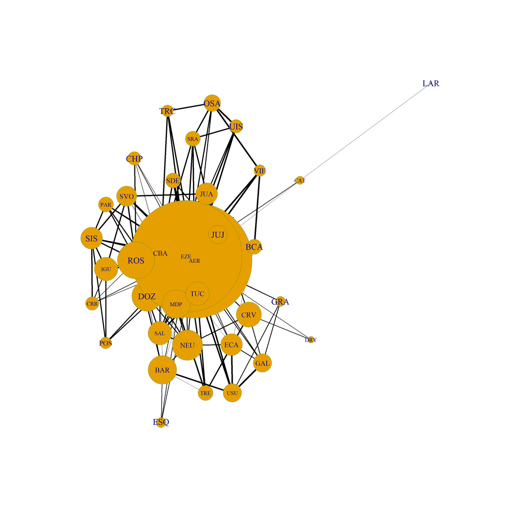

```r
# Tomo el dataframe del grafo y pido que no sea dirigido
grafo <- graph.data.frame(frec.viajes, directed = F)


plot.igraph( grafo,
             vertex.frame.color = "Forestgreen",
             vertex.size=degree(grafo, mode = "out"),
             vertex.label.cex=c(2,2.5,3),
             vertex.label.dist=0,
             edge.color="black",
             edge.curved = F,
             edge.width = E(grafo)/30)
```

En el grafo se puede visualizar que la mayoria de los viajes salen o de `EZE` o de `AER`. Entonces, tendria sentido preguntarse si hay alguna diferencia entre los vuelos que salen de `EZE` (o llegan) y los de `AER`.

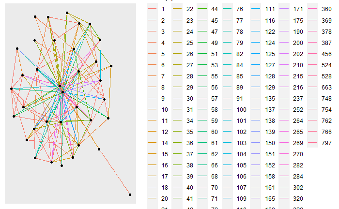

```r
graph <- graph_from_data_frame(frec.viajes)
ggraph(graph, layout = 'kk') +  geom_edge_link(aes(colour = factor(n))) + geom_node_point()
```

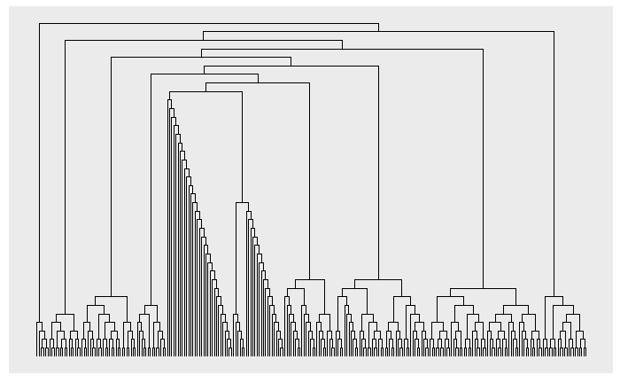

```r
layout <- create_layout(graph, layout = 'drl')

dendrogram <- as.dendrogram(hclust(dist(frec.viajes$n)))
ggraph(dendrogram, 'dendrogram') +
    geom_edge_elbow()
```

```r
NA
NA
```

Hagamos el primer grafo, pero tomando un origen y viendo que pasa con cada uno de estos.

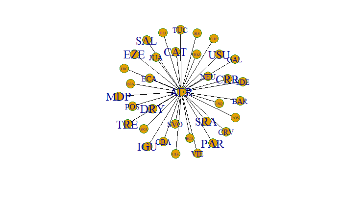

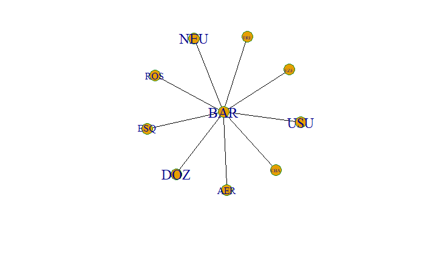

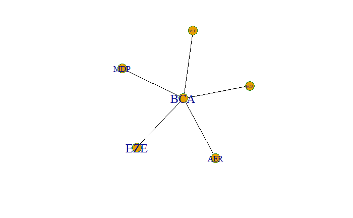

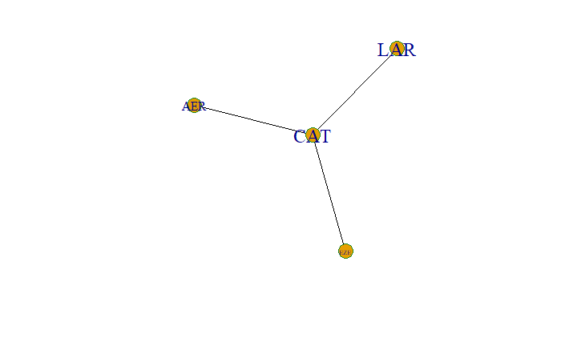

```r
grafica.grafo.origen <- function(df, filtro){
  # Filtra el dataset
  dt <- df %>% filter(Origen == filtro)
  # crea el grafo
  gf <- graph.data.frame(dt, directed = F)

  # Dibuja el grafo
  plot.igraph( gf,
             vertex.frame.color = "Forestgreen",
             vertex.label.cex=c(1.5,1,0.5),
             vertex.label.dist=0,
             edge.color="black",
             edge.curved = F,
             edge.width = E(gf)/30)
  }

nombres <- names(table(frec.viajes$Origen))

for (i in (1:4)){
  grafica.grafo.origen(frec.viajes, nombres[i])
}
```

```r
NA
NA
NA
```